# Lecture 7

Yeabin Moon

2022-09-14

# What’s today?

## 1. Transformation by whom?

It is ok to practice hard regarding the commands we learned the last time, however I did not emphasize much.

You might wonder why don’t we manipulate the data set and picture it instead of learning microscope details. For example, calculate relative frequency by group variables and just plot them.

I agree. But in this case, you need to learn how to manipulate data.

Let’s interpret the following codes:

```r
setwd("~/Documents/ibs_course/BUS240/data")
load('gss_sm.rda')

head(gss_sm, 10)
```

```
## # A tibble: 10 × 32
##     year    id ballot   age childs sibs  degree race  sex   region incom…¹ relig
##    <dbl> <dbl> <labe> <dbl>  <dbl> <lab> <fct>  <fct> <fct> <fct>  <fct>   <fct>
##  1  2016     1 1         47      3 2     Bache… White Male  New E… $17000… None
##  2  2016     2 2         61      0 3     High … White Male  New E… $50000… None
##  3  2016     3 3         72      2 3     Bache… White Male  New E… $75000… Cath…
##  4  2016     4 1         43      4 3     High … White Fema… New E… $17000… Cath…
##  5  2016     5 3         55      2 2     Gradu… White Fema… New E… $17000… None
##  6  2016     6 2         53      2 2     Junio… White Fema… New E… $60000… None
##  7  2016     7 1         50      2 2     High … White Male  New E… $17000… None
##  8  2016     8 3         23      3 6     High … Other Fema… Middl… $30000… Cath…
##  9  2016     9 1         45      3 5     High … Black Male  Middl… $60000… Prot…
## 10  2016    10 3         71      4 1     Junio… White Male  Middl… $60000… None
## # … with 20 more variables: marital <fct>, padeg <fct>, madeg <fct>,
## #   partyid <fct>, polviews <fct>, happy <fct>, partners <fct>, grass <fct>,
## #   zodiac <fct>, pres12 <labelled>, wtssall <dbl>, income_rc <fct>,
## #   agegrp <fct>, ageq <fct>, siblings <fct>, kids <fct>, religion <fct>,
## #   bigregion <fct>, partners_rc <fct>, obama <dbl>, and abbreviated variable
## #   name ¹income16
```

```r
# practice 1
religion_count <- gss_sm %>%
  group_by(religion) %>%
  summarize(N = n()) %>% arrange(-N)
religion_count
```

```
## # A tibble: 6 × 2
##   religion       N
##   <fct>      <int>
## 1 Protestant  1371
## 2 Catholic     649
## 3 None         619
## 4 Other        159
## 5 Jewish        51
## 6 <NA>          18
```

```r
# practice 2
rel_by_region <- gss_sm %>%
  group_by(bigregion, religion) %>%
  summarize(N = n()) %>%
  mutate(freq = N/sum(N), pct = round((freq*100),0))
rel_by_region
```

```
## # A tibble: 24 × 5
## # Groups:   bigregion [4]
##    bigregion religion       N    freq   pct
##    <fct>     <fct>      <int>   <dbl> <dbl>
##  1 Northeast Protestant   158 0.324      32
##  2 Northeast Catholic     162 0.332      33
##  3 Northeast Jewish        27 0.0553      6
##  4 Northeast None         112 0.230      23
##  5 Northeast Other         28 0.0574      6
##  6 Northeast <NA>           1 0.00205     0
##  7 Midwest   Protestant   325 0.468      47
##  8 Midwest   Catholic     172 0.247      25
##  9 Midwest   Jewish         3 0.00432     0
## 10 Midwest   None         157 0.226      23
## # … with 14 more rows
```

Need to check whether the grouping is correct:

```r
rel_by_region %>% group_by(bigregion) %>% summarize(total = sum(pct))
```

```
## # A tibble: 4 × 2
##   bigregion total
##   <fct>     <dbl>
## 1 Northeast   100
## 2 Midwest     101
## 3 South       100
## 4 West        101
```

Now plot it:

```r
p <- ggplot(rel_by_region, aes(x = bigregion, y = pct, fill = religion))
# what is the role of this line?
```

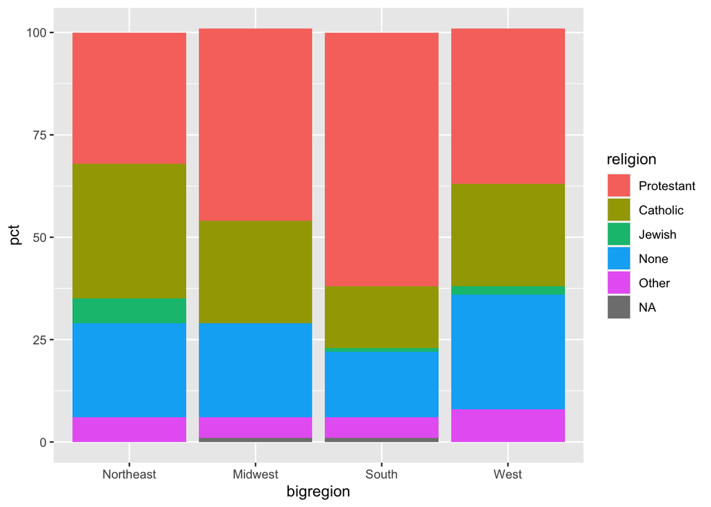

```r
p+geom_col() # why not using geom_bar?
```

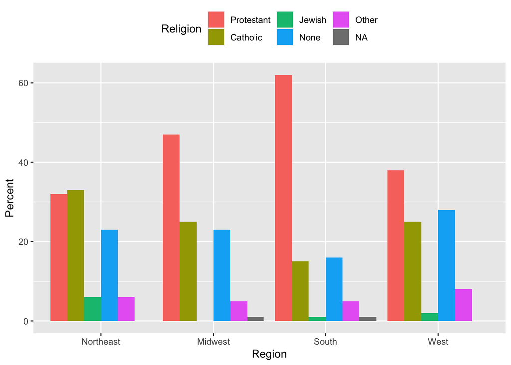

```r
p + geom_col(position = "dodge") +
    labs(x = "Region", y = "Percent", fill = "Religion")+
    theme(legend.position = "top")
```

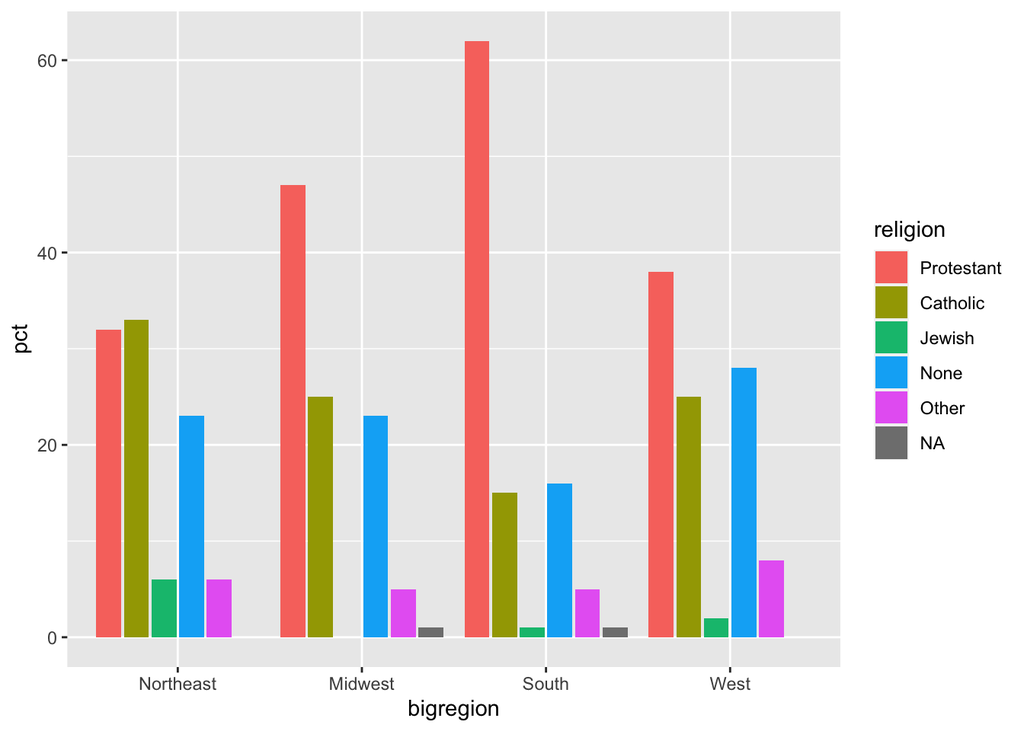

```r
p + geom_col(position = "dodge2")
```

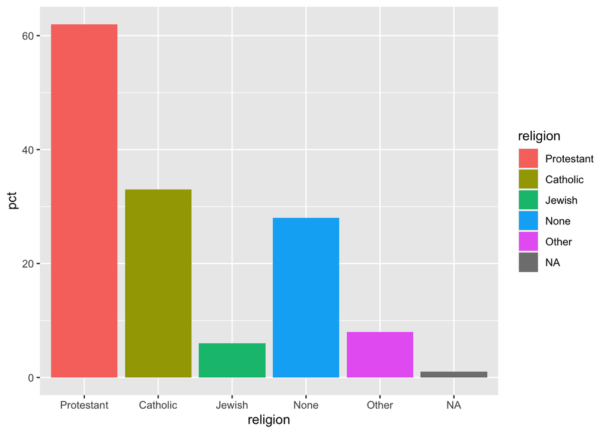

```r
p <- ggplot(rel_by_region, aes(x = religion, y = pct, fill = religion))
p + geom_col(position = "dodge")
```

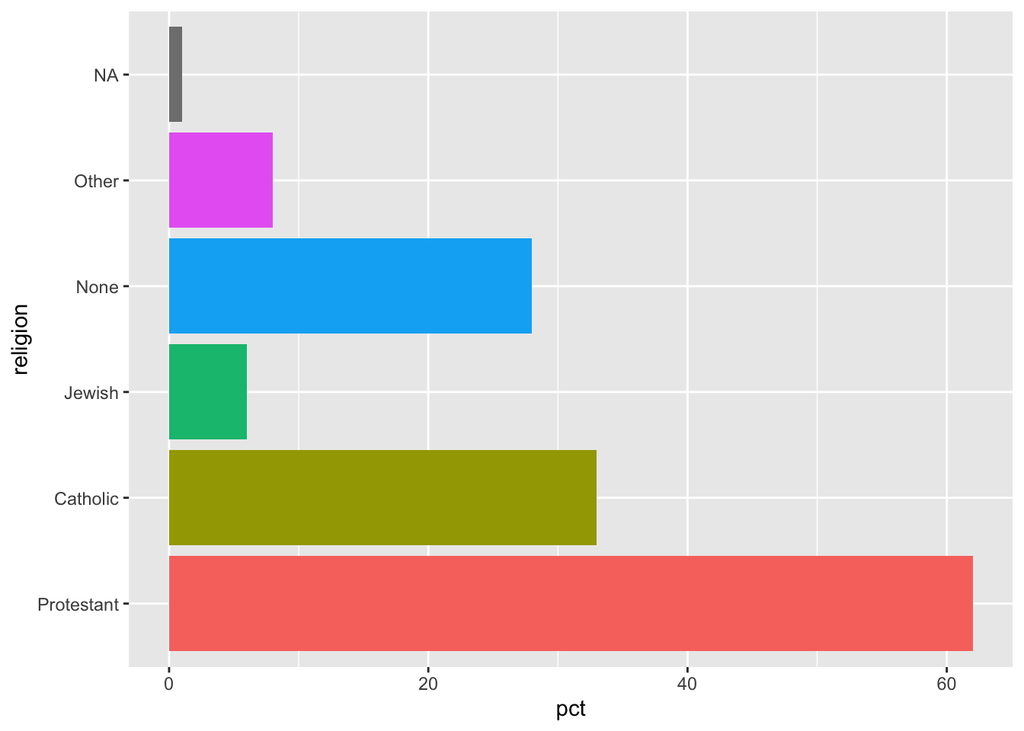

```r
p <- ggplot(rel_by_region, aes(x = religion, y = pct, fill = religion))
p + geom_col(position = "dodge") + guides(fill = "none") + coord_flip()
```

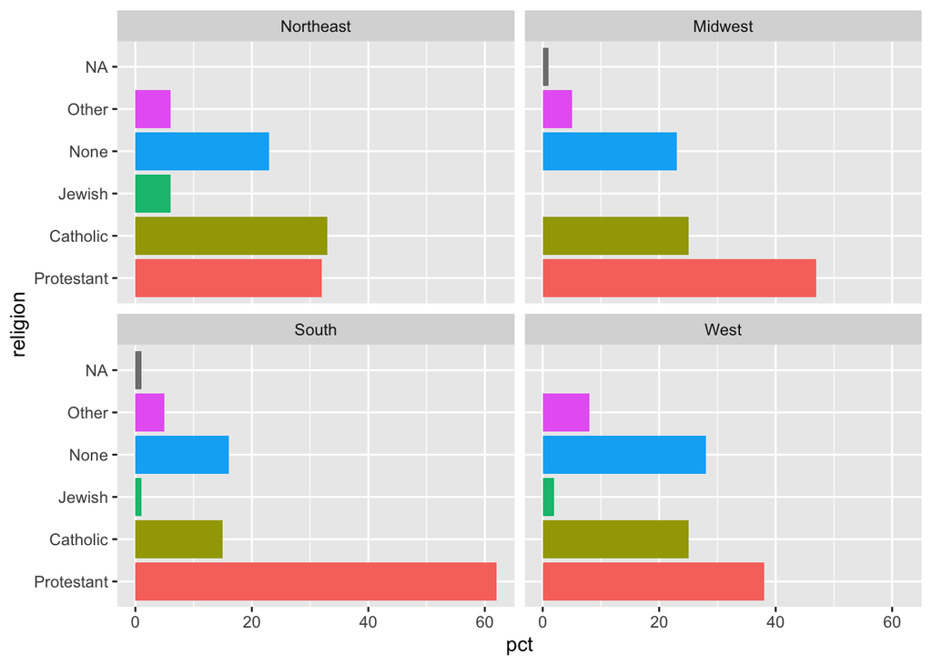

```r
p <- ggplot(rel_by_region, aes(x = religion, y = pct, fill = religion))
p + geom_col(position = "dodge") + guides(fill = "none") + coord_flip() +
    facet_wrap(~ bigregion)
```

The coord_flip() function switches the x and y axes after the plot is made. It does not remap variables to aesthetics.

Which way is better?

## 2.

Let’s use different dataset.

```r
setwd("~/Documents/ibs_course/BUS240/data")
load('organdata.rda')
head(organdata, 10)
```

```
## # A tibble: 10 × 21
##    country  year       donors   pop pop_d…¹   gdp gdp_lag health healt…² pubhe…³
##    <chr>    <date>      <dbl> <int>   <dbl> <int>   <int>  <dbl>   <dbl>   <dbl>
##  1 Austral… NA          NA    17065   0.220 16774   16591   1300    1224     4.8
##  2 Austral… 1991-01-01  12.1  17284   0.223 17171   16774   1379    1300     5.4
##  3 Austral… 1992-01-01  12.4  17495   0.226 17914   17171   1455    1379     5.4
##  4 Austral… 1993-01-01  12.5  17667   0.228 18883   17914   1540    1455     5.4
##  5 Austral… 1994-01-01  10.2  17855   0.231 19849   18883   1626    1540     5.4
##  6 Austral… 1995-01-01  10.2  18072   0.233 21079   19849   1737    1626     5.5
##  7 Austral… 1996-01-01  10.6  18311   0.237 21923   21079   1846    1737     5.6
##  8 Austral… 1997-01-01  10.3  18518   0.239 22961   21923   1948    1846     5.7
##  9 Austral… 1998-01-01  10.5  18711   0.242 24148   22961   2077    1948     5.9
## 10 Austral… 1999-01-01   8.67 18926   0.244 25445   24148   2231    2077     6.1
## # … with 11 more variables: roads <dbl>, cerebvas <int>, assault <int>,
## #   external <int>, txp_pop <dbl>, world <chr>, opt <chr>, consent_law <chr>,
## #   consent_practice <chr>, consistent <chr>, ccode <chr>, and abbreviated
## #   variable names ¹pop_dens, ²health_lag, ³pubhealth
```

It contains a little more than a decade’s worth of information on the donation of organs for transplants in seventeen OECD countries.

Let’s interpret the following commands

```r
organdata %>% select(1:6) %>% sample_n(size = 10)
```

```
## # A tibble: 10 × 6
##    country     year       donors   pop pop_dens   gdp
##    <chr>       <date>      <dbl> <int>    <dbl> <int>
##  1 Ireland     1992-01-01   19.5  3558    5.06  14241
##  2 Austria     1992-01-01   23.1  7841    9.35  20601
##  3 Netherlands 2002-01-01   12.6 16149   38.9   28983
##  4 Canada      1995-01-01   14.8 29354    0.294 22292
##  5 France      1996-01-01   15.1 58026   10.5   21990
##  6 France      1998-01-01   16.5 58398   10.6   24044
##  7 Italy       1994-01-01    7.9 57204   19.0   19903
##  8 Belgium     1993-01-01   21   10085   30.5   19733
##  9 Belgium     1997-01-01   22.5 10181   30.8   22936
## 10 Germany     1998-01-01   13.4 82047   23.0   23283
```

Lets’s start by naively graphing some of the data. We can take a look at a scatterplot of donors vs year.

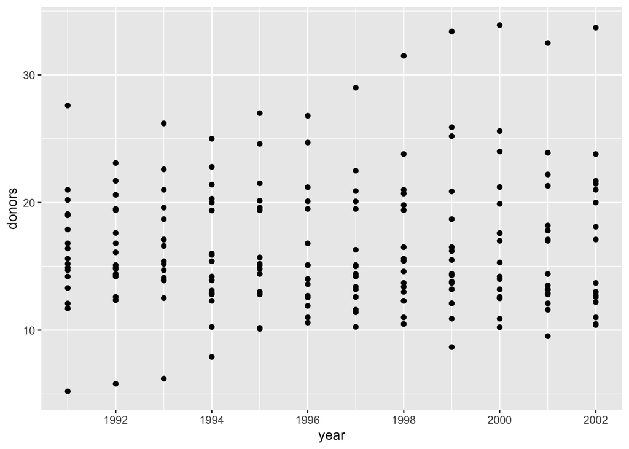

```r
p <- ggplot(organdata,aes(year,donors)) # when you practice, put all the argument names in
p + geom_point()
```

The graph looks too rough.

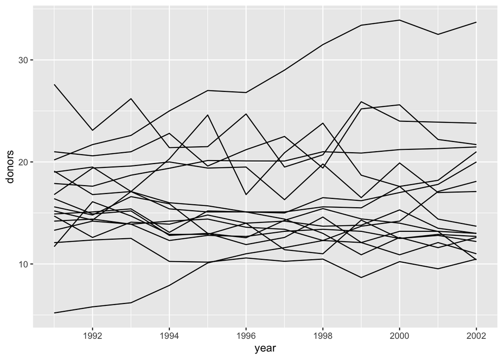

```r
p <- ggplot(data = organdata,
            mapping = aes(x = year, y = donors))
p + geom_line(aes(group = country))
```

Oh faceting. But need to check

```r
table(organdata$country)
```

```
##
##      Australia        Austria        Belgium         Canada        Denmark
##             14             14             14             14             14
##        Finland         France        Germany        Ireland          Italy
##             14             14             14             14             14
##    Netherlands         Norway          Spain         Sweden    Switzerland
##             14             14             14             14             14
## United Kingdom  United States
##             14             14
```

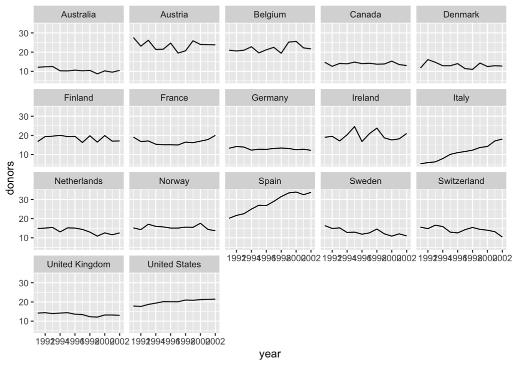

```r
p <- ggplot(data = organdata,
            mapping = aes(x = year, y = donors))
p + geom_line(aes(group = country)) + facet_wrap(~ country)
```

Let’s focus on the country-level variation ignoring time variation now. We can use geom_boxplot() to get a picture of variation by year across countries. Just as geom_bar() by default calculates a count of observations by the category you map to x, the stat_boxplot() function that works with geom_boxplot() will calculate a number of statistics that allow the box and whiskers to be drawn. We tell geom_boxplot() the variable we want to categorize by (here, country) and the continuous variable we want summarized (here, donors)

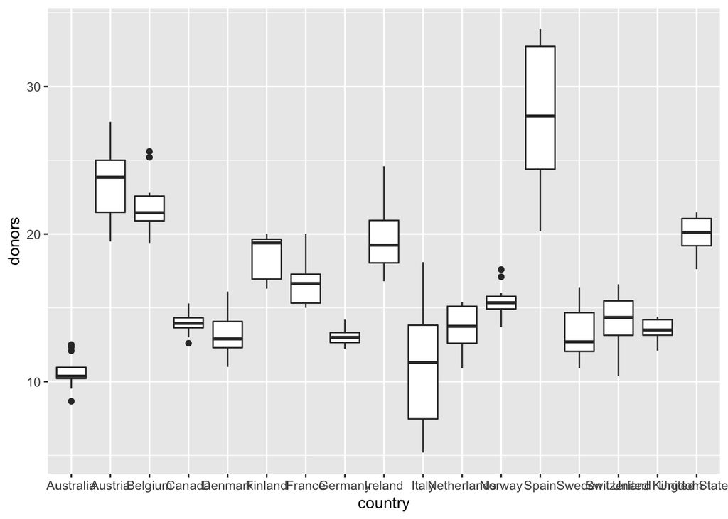

```r
p <- ggplot(data = organdata, mapping = aes(x = country, y = donors))
p + geom_boxplot()
```

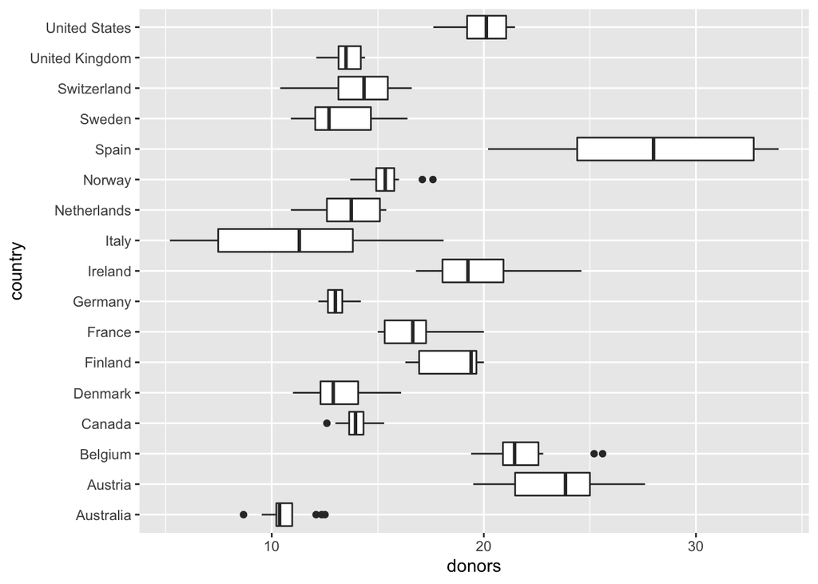

```r
p <- ggplot(data = organdata, mapping = aes(x = country, y = donors))
p + geom_boxplot() + coord_flip()
```

See the order of faceting plots and box plots.

More clever way is to have the countries listed from high to low average donation rate. Think about reordering the country variable by the mean of donors.

reorder() has two arguments: 1. the categorical variable or factor that we want to reorder 2. by what? need to indicate that variable If you only give reorder() the first two required arguments, then by default it will reorder the categories of your first variable by the mean value of the second

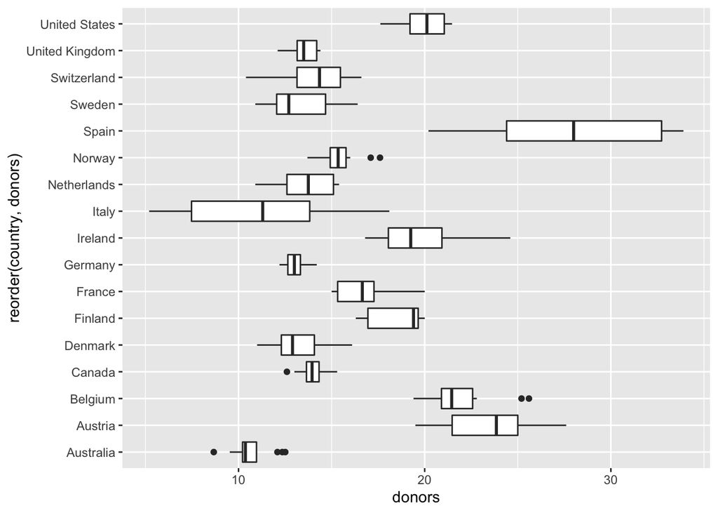

```r
p <- ggplot(data = organdata,
            mapping = aes(x = reorder(country, donors),
                          y = donors))
p + geom_boxplot() + coord_flip()
```

Well, it did not work out well. See:

```r
vec1 <- c(1,2,3)
vec2 <- c(4,5,NA)
mean(vec1)
```

```
## [1] 2
```

```r
mean(vec2)
```

```
## [1] NA
```

```r
mean(vec2, na.rm = TRUE)
```

```
## [1] 4.5
```

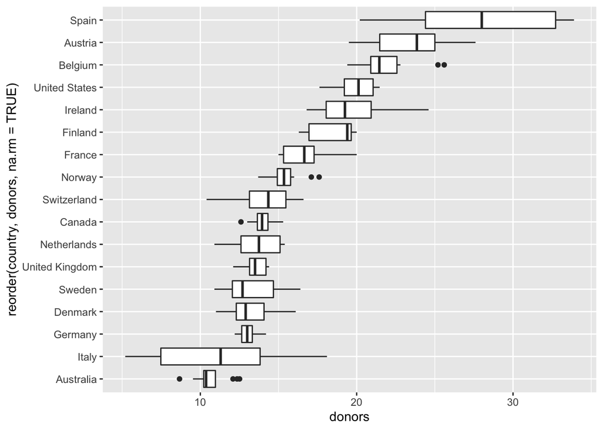

```r
p <- ggplot(data = organdata,
            mapping = aes(x = reorder(country, donors, na.rm = TRUE),
                          y = donors))
p + geom_boxplot() + coord_flip()
```

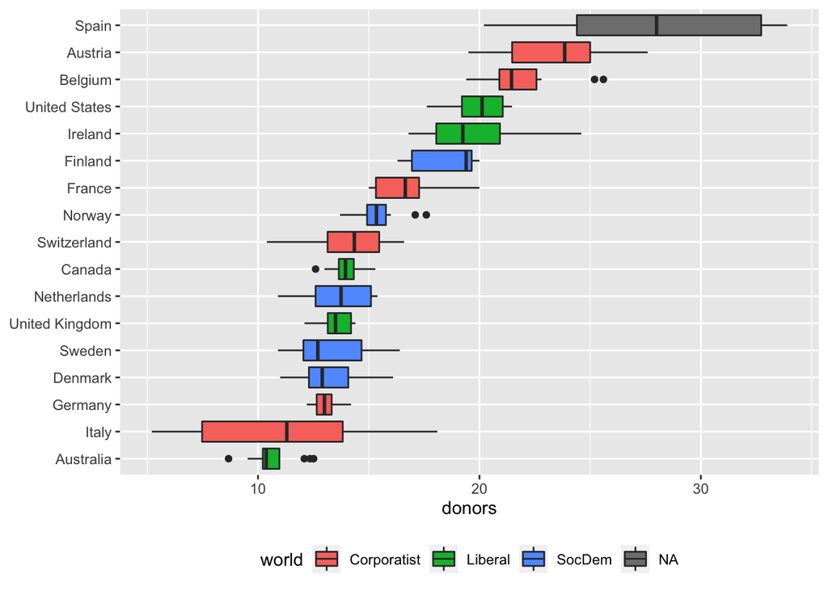

```r
p <- ggplot(data = organdata,
            mapping = aes(x = reorder(country, donors, na.rm = TRUE),
                          y = donors,
                          fill = world))
p + geom_boxplot() + coord_flip() + theme(legend.position = "bottom") +
  labs(x = NULL)
```

#### Just a matter of representation

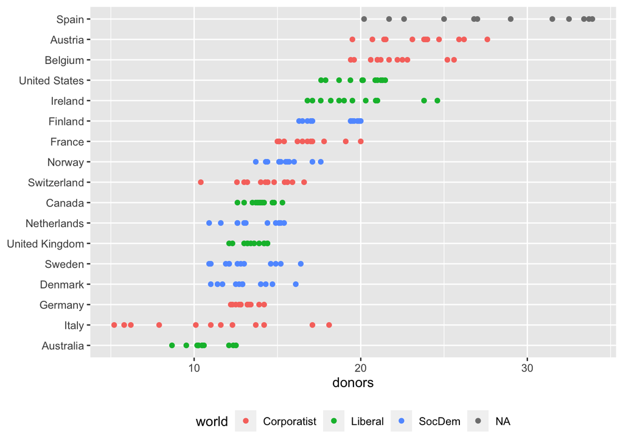

```r
p <- ggplot(data = organdata,
            mapping = aes(x = reorder(country, donors, na.rm = TRUE),
                          y = donors,
                          color = world))
p + geom_point() + coord_flip() + theme(legend.position = "bottom") +
  labs(x = NULL)
```

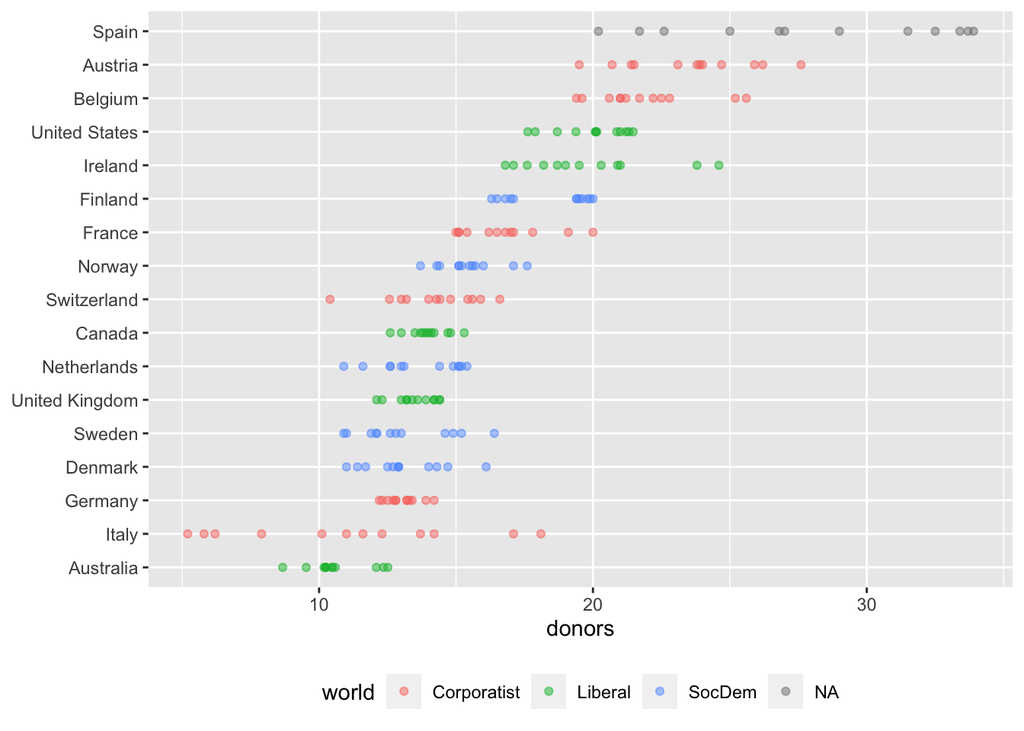

```r
p <- ggplot(data = organdata,
            mapping = aes(x = reorder(country, donors, na.rm = TRUE),
                          y = donors,
                          color = world))
p + geom_point(alpha = .5) + coord_flip() + theme(legend.position = "bottom") +
  labs(x = NULL)
```

geom_jitter works much like geom_point(), but randomly nudges each observation by a small amount.

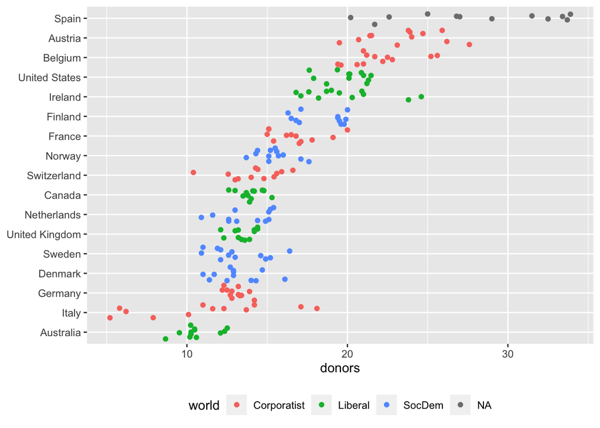

```r
p <- ggplot(data = organdata,
            mapping = aes(x = reorder(country, donors, na.rm = TRUE),
                          y = donors,
                          color = world))
p + geom_jitter() + coord_flip() + theme(legend.position = "bottom") +
  labs(x = NULL)
```

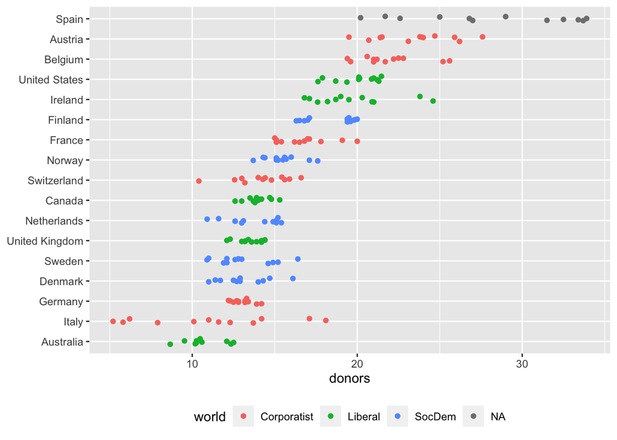

```r
p <- ggplot(data = organdata,
            mapping = aes(x = reorder(country, donors, na.rm = TRUE),
                          y = donors,
                          color = world))
p + geom_jitter(position = position_jitter(width = .15)) + coord_flip() + theme(legend.position = "bottom") +
  labs(x = NULL)
```